# Gene Regulation III - Lecture

## *aka* Gene Regulatory Network (GRN)

### & *aka* What your data is really telling you

UMass Chan GSBS BBS764

*Lingfei Wang*

2025-02-28

## Mechanisms of gene regulation

- Transcription factor (TF) binding to DNA
- DNA methylation
- Histone modification
- MicroRNA & other post-transcriptional regulations
- Post-translational regulation
- And many more...
- Forming a gene regulatory network (GRN)
- Network - What
- Gene regulatory network - What & why
- Gene regulatory network - Theoretically how: the good, the bad, and the ugly
- Gene regulatory network - Practically how
- Gene regulatory network analysis

## Network - What

| Artificial neural network | Internet | Traffic network |
| --- | --- | --- |
| **PPI network** | **Phylogenetic tree** | **Social network** |

## Network - Example

[figure not shown]

- Network/graph: collection of nodes and edges
- Nodes: entities
- Node properties: name, gender, age, etc
- Edges: relationships between nodes
- Edge properties
  - Type: like, fight, went to birthday party, etc
  - Other properties: direction (or not), strength, frequency, etc

## Network - Exercise

Choose a network and define its nodes, edges, and their properties.

| Artificial neural network | Internet | Traffic network |
| --- | --- | --- |
| **PPI network** | **Phylogenetic tree** | **Your own network** |

## Gene regulatory network - "What" in simplest form

- Nodes: genes
- Node properties: name
- Edges: gene relationships
- Edge properties
  - Type: gene regulation - one gene's expression level depends on another, either directly or through other genes
  - Direction: which is regulator and which is target
  - Regulation strength (optional)
- Disclaimers
  - Not TF binding network: other mechanisms and inactive binding
  - Not co-expression network
  - Not static: context specific and dynamically rewired

## Gene regulatory network - Why

- Understanding individual genes

| Social network | Gene regulatory network |
| --- | --- |

- Understanding system behavior
  - Cell homeostasis, response, fate, and interaction with environment and other cells
  - Organismal response to pathogens or other environmental changes
  - Disease mechanism and susceptibility
- Informing interventional applications
  - Predicting perturbation outcome
  - Directing cells to a certain state or fate
  - Developing (personalized) therapeutics

## Gene regulatory network - Status

- **Reconstruct** -> analyze
- Ancient field: ChIP microarray on yeast over 20 years ago
- Hard problem: still low accuracy today
- Limited knowledge: not static
- Opportunity from single cell and spatial technologies: data volume, resolution, and modality

The Bad - Illustration

We often find two genes in data go up and down together. Does that mean one regulates the other?

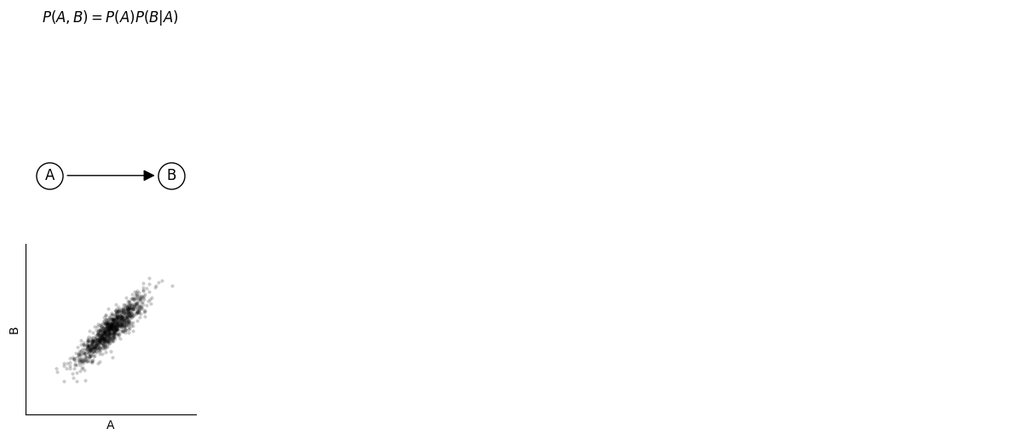

The Bad - Illustration

We often find two genes in data go up and down together. Does that mean one regulates the other?

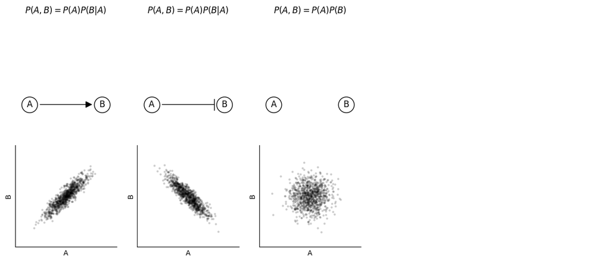

The Bad - Group exercise

Form a group of 2-3 people. Each person choose 1-2 networks from the following. For each network:

1. Write down the decomposition of distribution

2. Draw a schematic scatter plot for A and B

3. Convince your group members with your answers

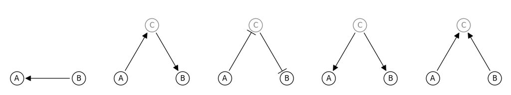

- Gray nodes: unmodelled or unobserved nodes (not finally needed in scatter plot)

- '->' edges: positive regulation/activation

- '-|' edges: negative regulation/repression

The Bad - Solutions

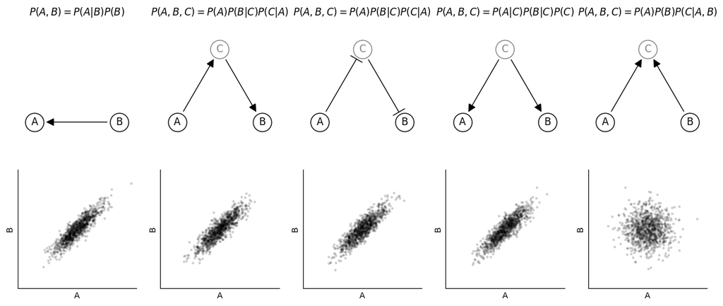

The Ugly - Cases with positive correlation

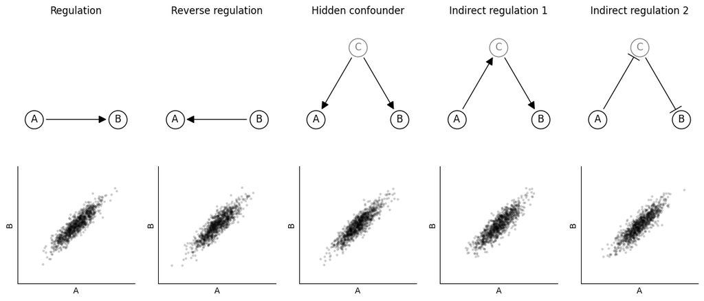

The Ugly - Cases with positive correlation

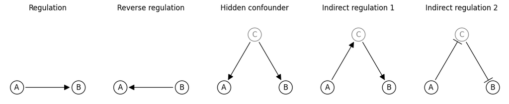

1. **Now imagine a stronger constraint. To conclude A->B, we additionally require A to be a TF that binds to a candidate cis-regulatory element (CRE) of B besides the correlation between A and B. Will this approach correctly include/exclude each of the 5 cases above?**
2. **Now consider a different approach. Instead of using correlation, this new approach fits a function $f$ to predict $B$ with $A$ i.e. $B=f(A)$. If we can find a function to fit data well, this approach will conclude A->B. Is this approach better?**

## The Good - Randomized controlled trials

[figure not shown]

Highly mature and successful study design used for drug approval world-wide e.g. FDA.

- Goal: testing whether (E)xposure to a treatment affects the (O)utcome of a disease.
- Trial design
  - (G)roup patients into two randomly and double-blindedly
  - Give one group actual treatment and the other group placebo
  - Test whether disease outcome differs between two groups

## The Good - Randomized controlled trials

[figure not shown]

In other words:

- Goal: testing E->O
- Design: introduce G->E and test G->O
- Hypothesized relationship: G->E->O

Swapping the alphabet for gene regulatory network:

- Goal: testing A->B
- Design: introduce perturbation P->A and test P->B
- Hypothesized relationship: P->A->B

The Good - Illustration with continuous perturbation

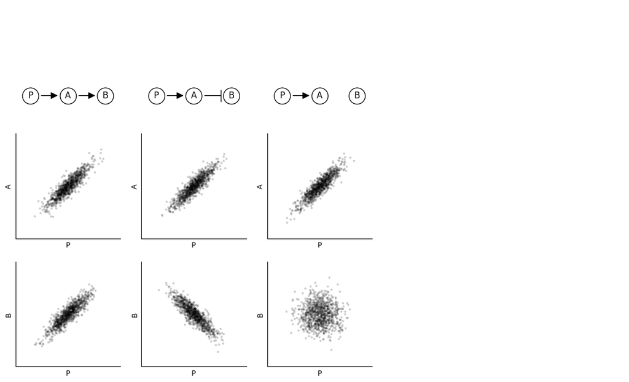

The Good - Illustration with binary perturbation

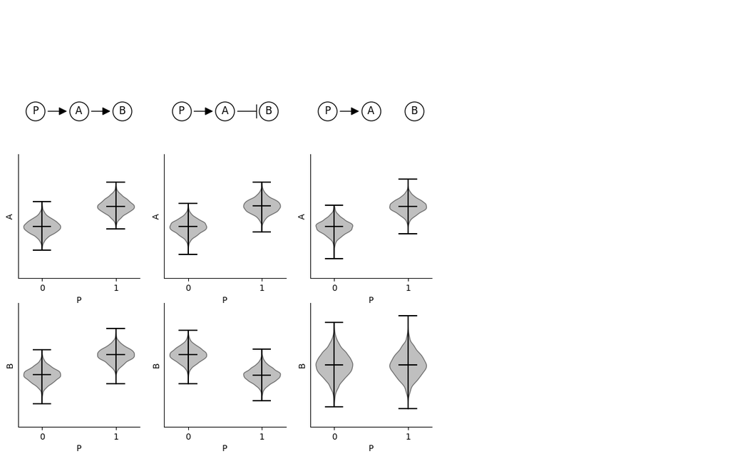

The Good - Group exercise

Form a group of 2-3 people. Each person choose 1-2 networks from the following. For each network:

1. Draw two schematic violin plots between P and A and between P and B

2. Convince your group members with your answers

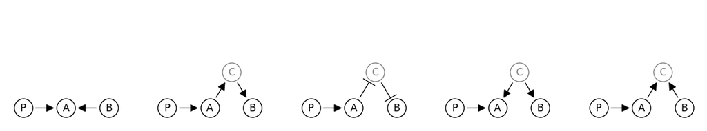

- Gray nodes: unmodelled or unobserved nodes (not needed in violin plot)

- '->' edges: positive regulation

- '-|' edges: negative regulation

The Good - Solutions

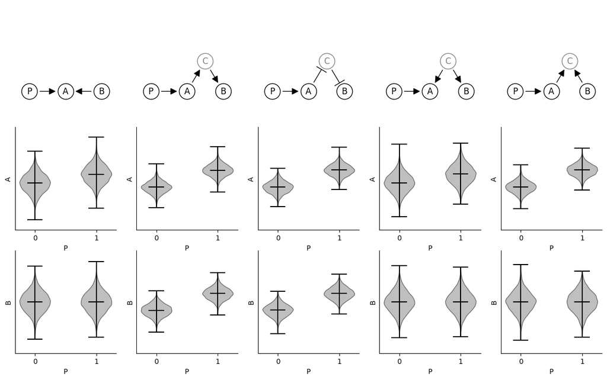

The Good - Cases with differential expression

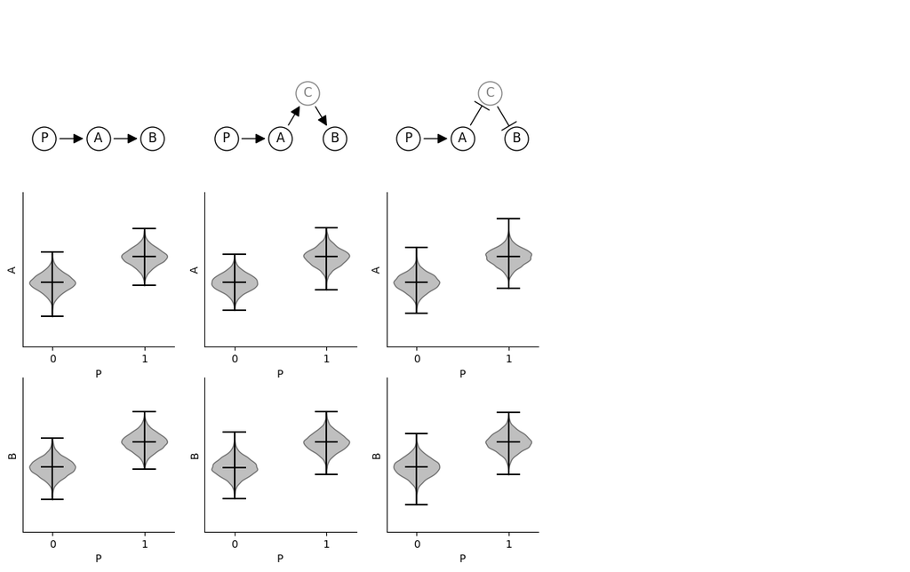

The Ugly - Cases with positive correlation and other challenges

- Problems solved/not solved

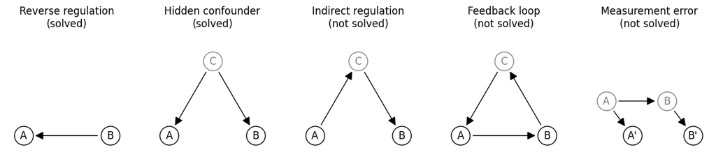

- Context specificity & scalability

- Biological mechanistic knowledge: direct or indirect, but how?

- Groundtruth availability: which method is best?

- Perfect perturbation availability

## Practically how - Artificial Perturbations

Molecular biology

High-throughput experiments

[figure not shown]

Pros:

- Straightforward
- Many assays
- Gold standard

Pros:

- High throughput
- Easy to scale up

Cons:

- Low throughput

Cons:

- Imperfect perturbations
- Hard for primary cells

## Practically how - Natural perturbations

[figure not shown]

Pros

Cons

- Known as Mendelian randomization in GWAS
- Better than on GWAS
- Many primary cell types
- Not so perfect perturbations
- Costly

## Gene regulatory network analysis

- Node level
  - Centrality measure e.g. TF activity
  - Gene modules
- Edge level
  - Gene regulation inference
  - Network rewiring
- System level
  - Cell identity, function, response, and fate determination
  - Perturbation outcome prediction: node and edge